```r
## make predictions on the hold-out set
predvals <- predict(forestfit, holdoutTransformed)

## create the confusion matrix and view the results
confusionMatrix(predvals, holdoutTransformed$Chest.pain.type, positive = "more.than.50.pct")
```

```
## Confusion Matrix and Statistics
##
##           Reference
## Prediction TA ATA NAP ASY
##        TA   0   0   0   0
##        ATA  0   0   4   2
##        NAP  1   6   4   6
##        ASY  3   2   7  17
##
## Overall Statistics
##
##                Accuracy : 0.4038
##                  95% CI : (0.2701, 0.549)
##     No Information Rate : 0.4808
##     P-Value [Acc > NIR] : 0.8946
##
##                   Kappa : 0.0382
##
##  Mcnemar's Test P-Value : NA
##
## Statistics by Class:
##
##                      Class: TA Class: ATA Class: NAP Class: ASY
## Sensitivity            0.00000     0.0000    0.26667     0.6800
## Specificity            1.00000     0.8636    0.64865     0.5556
## Pos Pred Value             NaN     0.0000    0.23529     0.5862
## Neg Pred Value         0.92308     0.8261    0.68571     0.6522
## Prevalence             0.07692     0.1538    0.28846     0.4808
## Detection Rate         0.00000     0.0000    0.07692     0.3269
## Detection Prevalence   0.00000     0.1154    0.32692     0.5577
## Balanced Accuracy      0.50000     0.4318    0.45766     0.6178
```

```r
## Rank the variables in terms of their importance
varImp(forestfit)
```

```
## rf variable importance
##
##                                         Overall
## Max.HR                                  100.000
## Cholesterol                              93.205
## Age                                      89.834
## BP                                       84.069
## ST.depression                            67.901
## Exercise.anginayes                       52.075
## EKG.resultsventricular.hypertrophy       21.903
## Thalliumreversible.defect                21.354
## Number.of.vessels.fluromore.than.50.pct  20.074
## SexM                                     17.847
## Slope.of.STflat                          17.637
## FBS.over.120true                         14.622
## Thalliumfixed.defect                      5.719
## Slope.of.STdownsloping                    4.508
## EKG.resultswave.abnormality               0.000
```

```r
## next, let's identify an optimal boosted-tree model
## Consulting the documentation, https://topepo.github.io/caret/train-models-by-tag.html#boosting
## we find that there are several implementations of boosted models available
## to be consistent with chapter 8 in the book, we will use the package gbm
## and the gbm method present in it for fitting an optimal boosted-tree model.
## all of the initial set-up steps will remain the same. The changes (new code)
## begin(s) with setting up the dataframe that has method-specific parameters
## and their ranges of values. The specific columns to use are described
## in the gbm documentation:
# Tuning parameters:
#   n.trees (# Boosting Iterations)
#     interaction.depth (Max Tree Depth)
#     shrinkage (Shrinkage)
#     n.minobsinnode (Min. Terminal Node Size)

grid <- expand.grid(interaction.depth = seq(1:3),
                    shrinkage = seq(from = 0.01, to = 0.2, by = 0.01),
                    n.trees = seq(from = 100, to = 500, by = 100),
                    n.minobsinnode = seq(from = 5, to = 15, by = 5)
)


boostedfit <- train(Chest.pain.type ~ .,
                    data = trainTransformed,
                    method = "gbm",
                    trControl = fitControl,
                    verbose = FALSE,
                    tuneGrid = grid)
## check what information is available for the model fit
names(boostedfit)
```

```
##  [1] "method"       "modelInfo"    "modelType"    "results"      "pred"
##  [6] "bestTune"     "call"         "dots"         "metric"       "control"
## [11] "finalModel"   "preProcess"   "trainingData" "ptype"        "resample"
## [16] "resampledCM"  "perfNames"    "maximize"     "yLimits"      "times"
## [21] "levels"       "terms"        "coefnames"    "contrasts"    "xlevels"
```

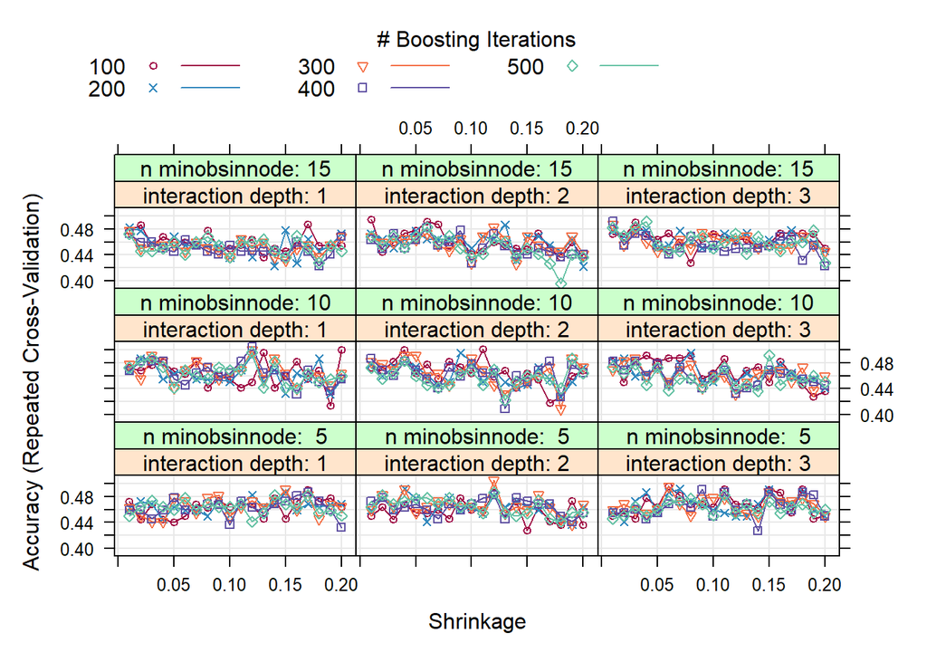

```r
## some plots
trellis.par.set(caretTheme())
plot(boostedfit)
```

```r
## make predictions on the hold-out set
predvals <- predict(boostedfit, holdoutTransformed)

## compute the performance metrics
confusionMatrix(predvals, holdoutTransformed$Chest.pain.type)
```

```
## Confusion Matrix and Statistics
##
##           Reference
## Prediction TA ATA NAP ASY
##        TA   0   0   3   1
##        ATA  1   1   5   3
##        NAP  0   3   4   5
##        ASY  3   4   3  16
##
## Overall Statistics
##
##                Accuracy : 0.4038
##                  95% CI : (0.2701, 0.549)
##     No Information Rate : 0.4808
##     P-Value [Acc > NIR] : 0.8946
##
##                   Kappa : 0.0934
##
##  Mcnemar's Test P-Value : 0.4074
##
## Statistics by Class:
##
##                      Class: TA Class: ATA Class: NAP Class: ASY
## Sensitivity            0.00000    0.12500    0.26667     0.6400
## Specificity            0.91667    0.79545    0.78378     0.6296
## Pos Pred Value         0.00000    0.10000    0.33333     0.6154
## Neg Pred Value         0.91667    0.83333    0.72500     0.6538
## Prevalence             0.07692    0.15385    0.28846     0.4808
## Detection Rate         0.00000    0.01923    0.07692     0.3077
## Detection Prevalence   0.07692    0.19231    0.23077     0.5000
## Balanced Accuracy      0.45833    0.46023    0.52523     0.6348
```

```r
## Rank the variables in terms of their importance
varImp(boostedfit)
```

```
## gbm variable importance
##
##                                           Overall
## Max.HR                                  100.00000
## Cholesterol                              91.61395
## Age                                      75.59574
## BP                                       70.73654
## ST.depression                            37.43820
## Exercise.anginayes                       18.18513
## Thalliumreversible.defect                 9.01262
## SexM                                      7.14636
## EKG.resultsventricular.hypertrophy        6.67734
## FBS.over.120true                          6.26255
## Number.of.vessels.fluromore.than.50.pct   4.57975
## Slope.of.STflat                           3.30890
## Thalliumfixed.defect                      0.38169
## Slope.of.STdownsloping                    0.04615
## EKG.resultswave.abnormality               0.00000
```

```r
## make predictions on the hold-out set
predvals.boosted <- predict(boostedfit, holdoutTransformed)
#
# ## compute the performance metrics
postres.boosted <-  postResample(pred = predvals.boosted, obs = holdoutTransformed$Chest.pain.type)

## Rank the variables in terms of their importance
varImp(boostedfit)
```

```
## gbm variable importance
##
##                                           Overall
## Max.HR                                  100.00000
## Cholesterol                              91.61395
## Age                                      75.59574
## BP                                       70.73654
## ST.depression                            37.43820
## Exercise.anginayes                       18.18513
## Thalliumreversible.defect                 9.01262
## SexM                                      7.14636
## EKG.resultsventricular.hypertrophy        6.67734
## FBS.over.120true                          6.26255
## Number.of.vessels.fluromore.than.50.pct   4.57975
## Slope.of.STflat                           3.30890
## Thalliumfixed.defect                      0.38169
## Slope.of.STdownsloping                    0.04615
## EKG.resultswave.abnormality               0.00000
```

```r
#SVM - linear kernel
grid <- expand.grid(C = c(0.01, 0.1, 10, 100, 1000)) #C is cost

svmlinearfit <- train(Chest.pain.type ~ .,
                      data = trainTransformed,
                      method = "svmLinear",
                      trControl = fitControl,
                      verbose = FALSE,
                      tuneGrid = grid)

## check what information is available for the model fit
names(svmlinearfit)
```

```
##  [1] "method"       "modelInfo"    "modelType"    "results"      "pred"
##  [6] "bestTune"     "call"         "dots"         "metric"       "control"
## [11] "finalModel"   "preProcess"   "trainingData" "ptype"        "resample"
## [16] "resampledCM"  "perfNames"    "maximize"     "yLimits"      "times"
## [21] "levels"       "terms"        "coefnames"    "contrasts"    "xlevels"
```

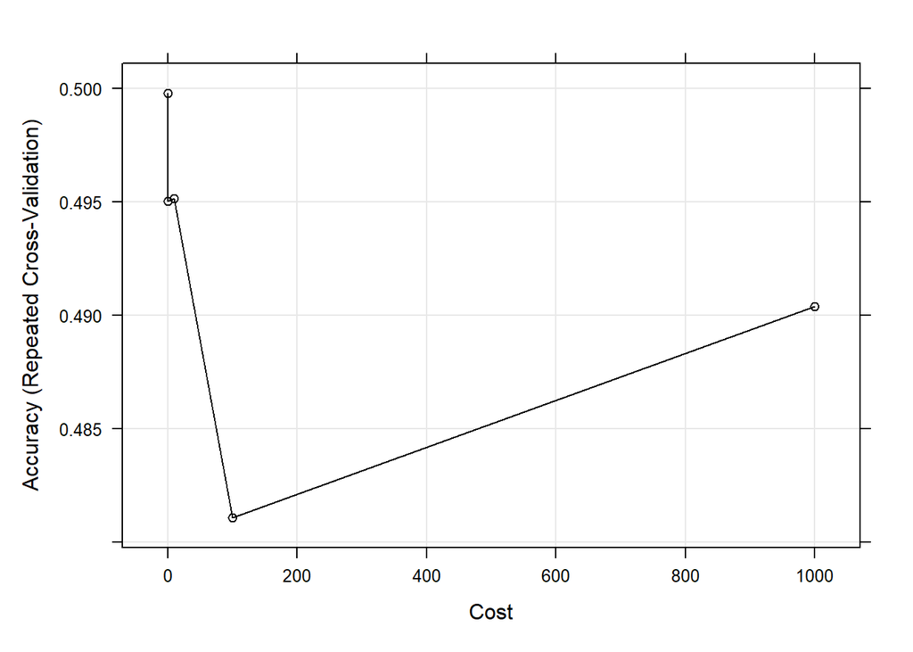

```r
## some plots
trellis.par.set(caretTheme())
plot(svmlinearfit)
```

```r
## make predictions on the hold-out set
predvals.svm.linear <- predict(svmlinearfit, holdoutTransformed)

## compute the performance metrics
postres.svm.linear <-  postResample(pred = predvals.svm.linear, obs = holdoutTransformed$Chest.pain.type)

## Rank the variables in terms of their importance
varImp(svmlinearfit)
```

```
## ROC curve variable importance
##
##   variables are sorted by maximum importance across the classes
##                             TA    ATA     NAP   ASY
## ST.depression           100.00 100.00 100.000 40.29
## BP                       84.29  84.29  84.286 75.58
## Exercise.angina           0.00  80.66   3.036 80.66
## Max.HR                   18.47  73.65  28.214 73.65
## Slope.of.ST              70.71  70.71  70.714 32.32
## EKG.results              63.57  63.57  63.571 43.52
## Age                      57.86  57.86  57.857 39.91
## Thallium                 18.57  44.00  18.571 44.00
## Sex                      38.39  25.00  25.000 38.39
## FBS.over.120             36.43  36.43  36.429 34.89
## Number.of.vessels.fluro  13.57  33.02  13.571 33.02
## Cholesterol              14.68  13.52  17.143 14.68
```

```r
## First, a comparison of performance on the training subset

resamps <- resamples(list(RF = forestfit,
                          GBM = boostedfit,
                          SVM = svmlinearfit))
resamps
```

```
##
## Call:
## resamples.default(x = list(RF = forestfit, GBM = boostedfit, SVM
##  = svmlinearfit))
##
## Models: RF, GBM, SVM
## Number of resamples: 5
## Performance metrics: Accuracy, Kappa
## Time estimates for: everything, final model fit
```

```r
summary(resamps)
```

```
##
## Call:
## summary.resamples(object = resamps)
##
## Models: RF, GBM, SVM
## Number of resamples: 5
##
## Accuracy
##          Min.   1st Qu.    Median      Mean   3rd Qu.      Max. NA's
## RF  0.5227273 0.5227273 0.5238095 0.5502165 0.5681818 0.6136364    0
## GBM 0.4318182 0.4883721 0.4888889 0.5050716 0.5348837 0.5813953    0
## SVM 0.4186047 0.4772727 0.5000000 0.4997886 0.5348837 0.5681818    0
##
## Kappa
##           Min.   1st Qu.    Median      Mean   3rd Qu.      Max. NA's
## RF  0.18762089 0.2075472 0.2156197 0.2605908 0.2915254 0.4006410    0
## GBM 0.08485857 0.1914530 0.2206325 0.2149098 0.2307692 0.3468354    0
## SVM 0.08898305 0.1779041 0.2013201 0.2025668 0.2436236 0.3010033    0
```

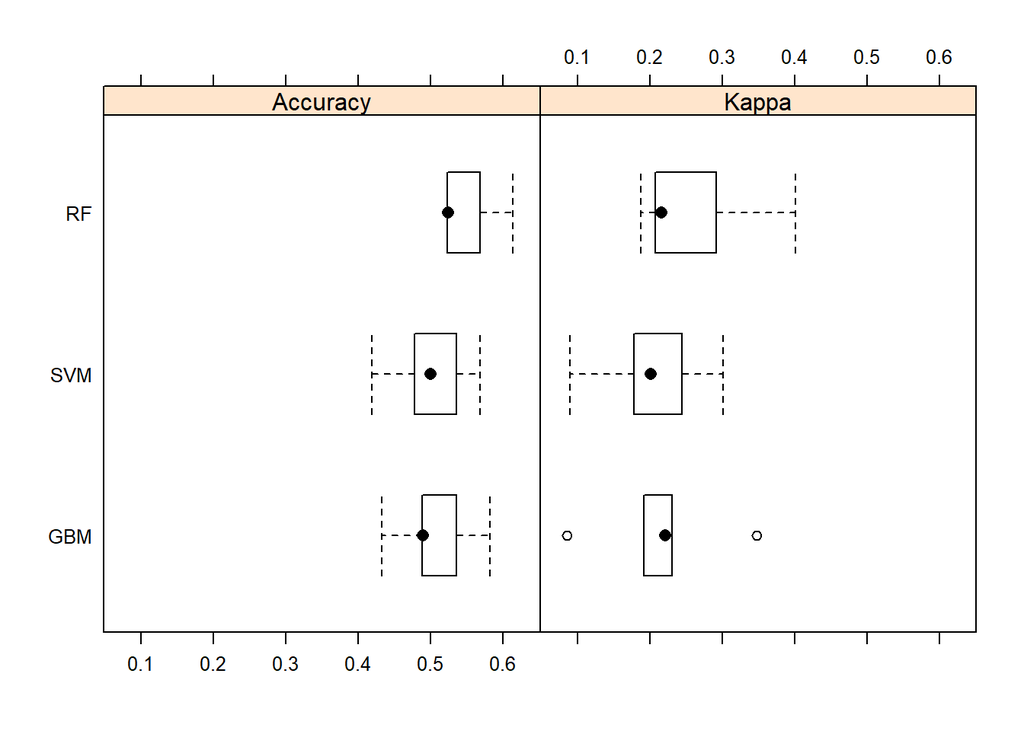

```r
bwplot(resamps)
```

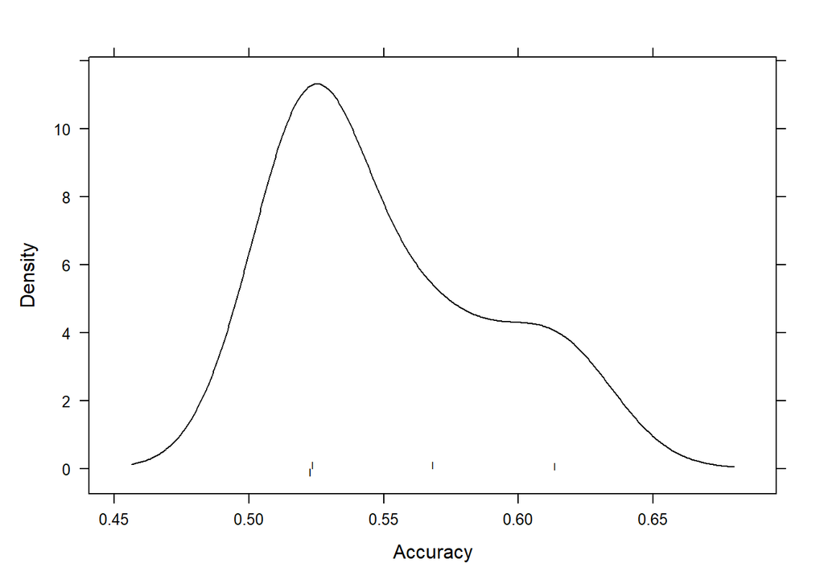

```r
stopCluster(cl)

densityplot(forestfit, pch = "l")
```

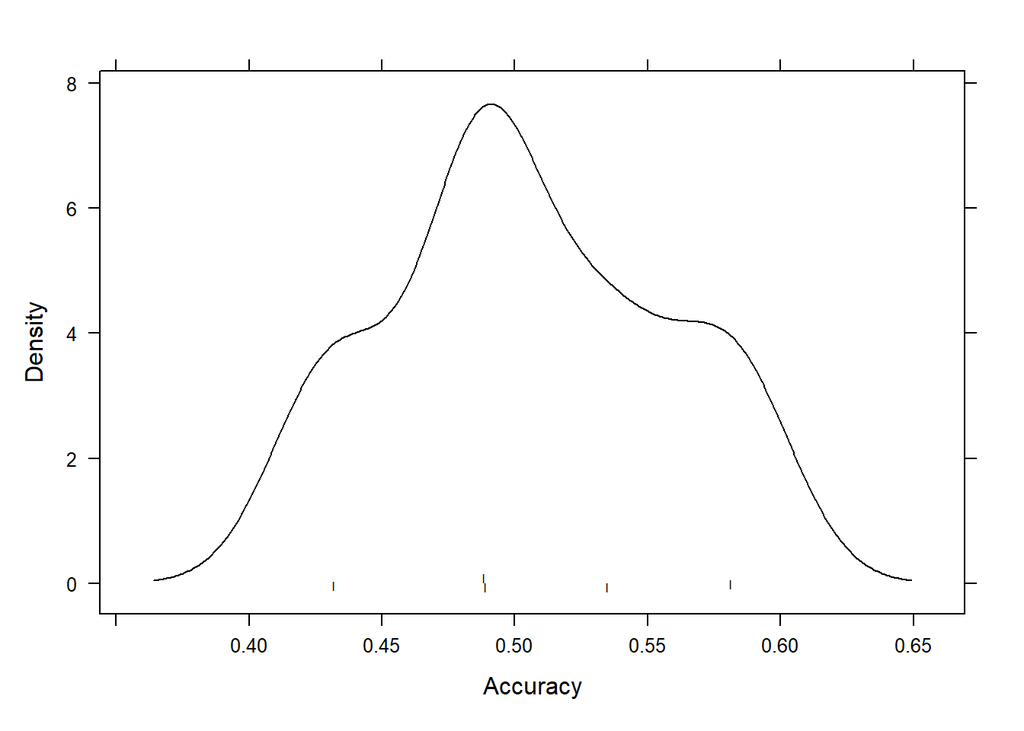

```r
densityplot(boostedfit, pch = "l")
```

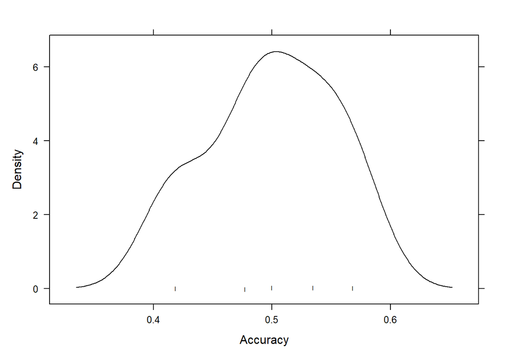

```r
densityplot(svmlinearfit, pch = "l")
```

```r
## compare performance variability across models
resamps <- resamples(list(RandomForest = forestfit,
                          GBM = boostedfit,
                          SVM.Linear = svmlinearfit))
summary(resamps)
```

```
##
## Call:
## summary.resamples(object = resamps)
##
## Models: RandomForest, GBM, SVM.Linear
## Number of resamples: 5
##
## Accuracy
##                   Min.   1st Qu.    Median      Mean   3rd Qu.      Max. NA's
## RandomForest 0.5227273 0.5227273 0.5238095 0.5502165 0.5681818 0.6136364    0
## GBM          0.4318182 0.4883721 0.4888889 0.5050716 0.5348837 0.5813953    0
## SVM.Linear   0.4186047 0.4772727 0.5000000 0.4997886 0.5348837 0.5681818    0
##
## Kappa
##                    Min.   1st Qu.    Median      Mean   3rd Qu.      Max. NA's
## RandomForest 0.18762089 0.2075472 0.2156197 0.2605908 0.2915254 0.4006410    0
## GBM          0.08485857 0.1914530 0.2206325 0.2149098 0.2307692 0.3468354    0
## SVM.Linear   0.08898305 0.1779041 0.2013201 0.2025668 0.2436236 0.3010033    0
```

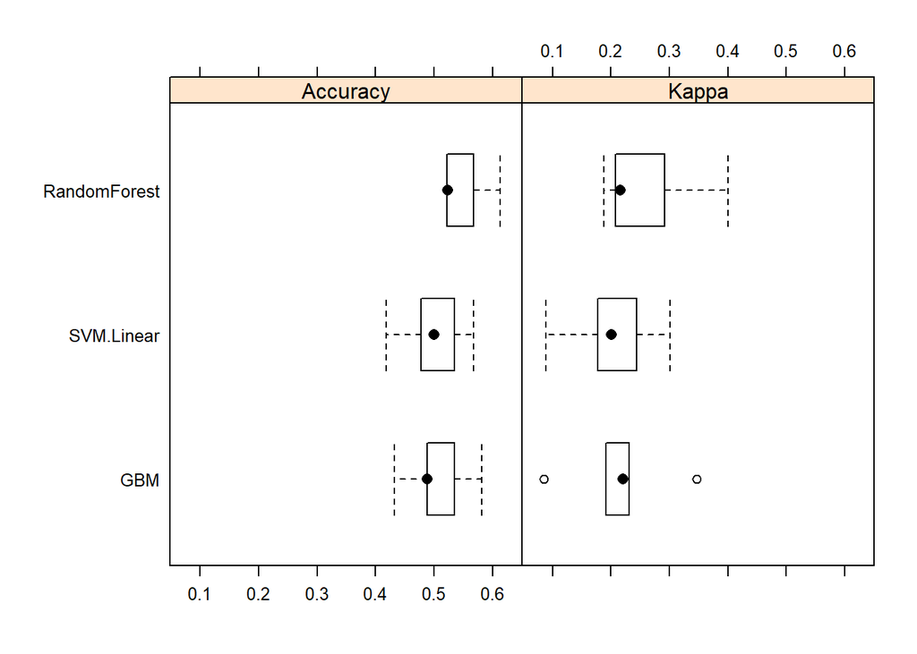

```r
## view the comparisons via graphs
bwplot(resamps)
```

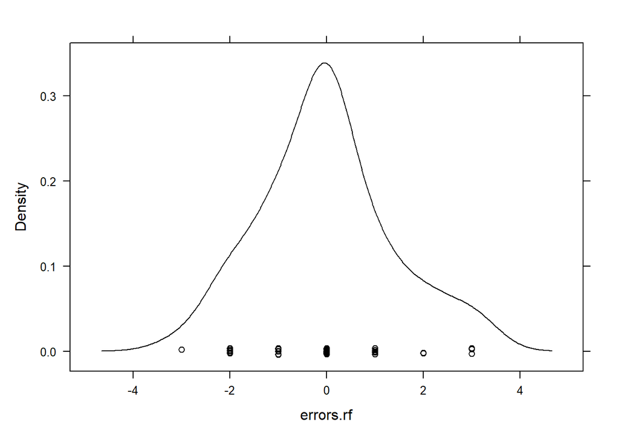

```r
## Now, let's look at variability in predictions on the holdout set
## compute the error vectors first
errors.rf <- as.numeric(predvals) - as.numeric(holdoutTransformed$Chest.pain.type)
errors.boosted <- as.numeric(predvals.boosted) - as.numeric(holdoutTransformed$Chest.pain.type)
errors.svm.linear <- as.numeric(predvals.svm.linear) - as.numeric(holdoutTransformed$Chest.pain.type)

#bwplot(resamps,

## Next, compare on the performance in predictions on the holdout subset
#errors.rf <- as.numeric(predvals) - as.numeric(holdoutTransformed$Chest.pain.type),
#errors.boosted <- as.numeric(predvals.boosted) - as.numeric(holdoutTransformed$Chest.pain.type),
#errors.svm.linear <- as.numeric(predvals.svm.linear) - as.numeric(holdoutTransformed$Chest.pain.type))

# Create density plots
library(lattice)
densityplot(errors.rf)
```

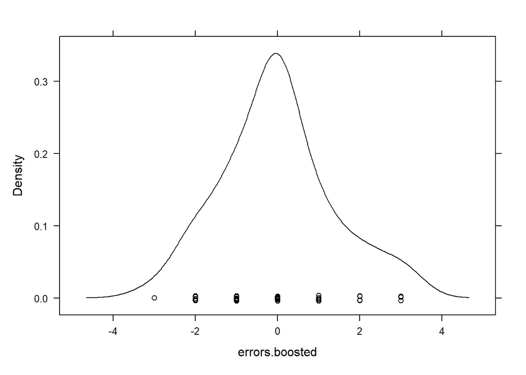

```r
densityplot(errors.boosted)
```

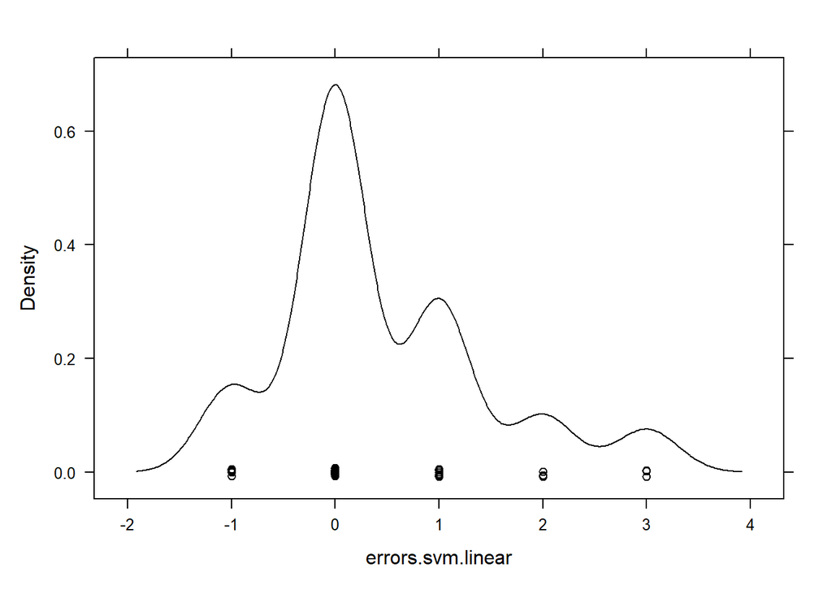

```r
densityplot(errors.svm.linear)
```

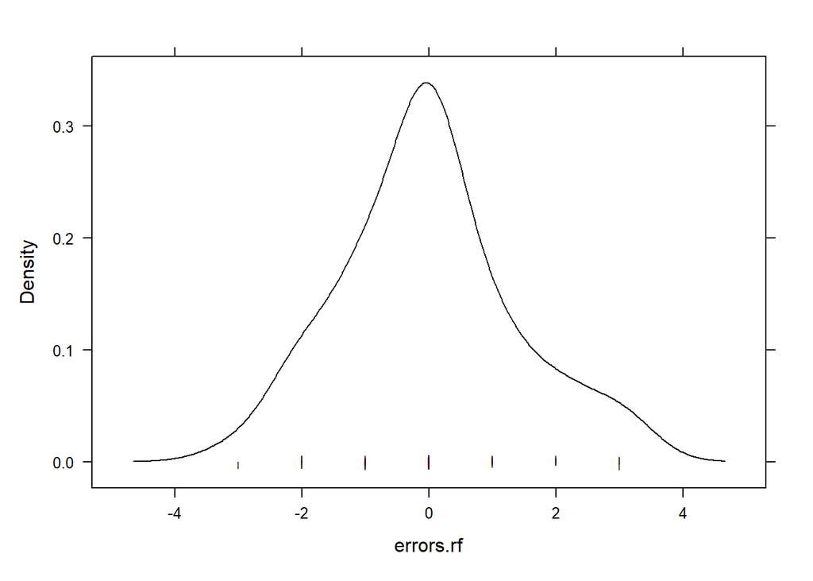

```r
densityplot(errors.rf, pch="l")
```

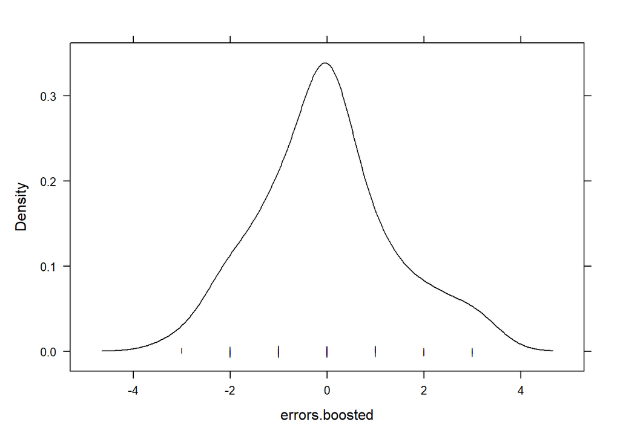

```r
densityplot(errors.boosted, pch="l")
```

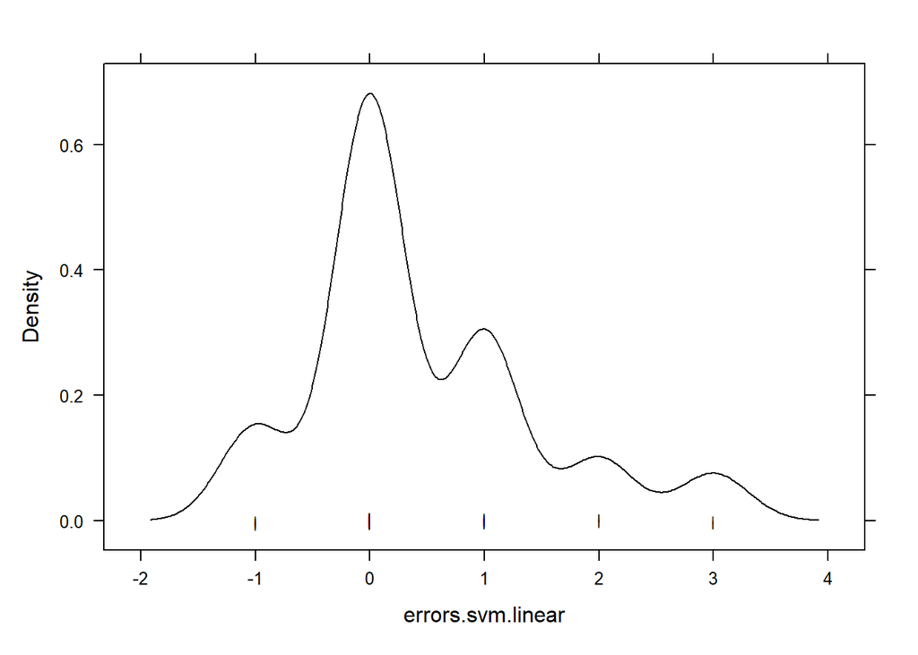

```r
densityplot(errors.svm.linear, pch="l")
```

```r
df.1 <- data.frame(error = errors.rf,
                   model = rep("randomforest", (length(errors.rf))))
df.2 <- data.frame(error = errors.boosted,
                   model = rep("gbm", (length(errors.boosted))))
df.3 <- data.frame(error = errors.svm.linear,
                   model = rep("svm.linear", (length(errors.svm.linear))))
df.total <- rbind(df.1, df.2, df.3)
df.total$model <- as.factor(df.total$model)
summary(df.total)
```

```
##      error                  model
##  Min.   :-3.0000   gbm         :52
##  1st Qu.:-1.0000   randomforest:52
##  Median : 0.0000   svm.linear  :52
##  Mean   : 0.1346
##  3rd Qu.: 1.0000
##  Max.   : 3.0000
```

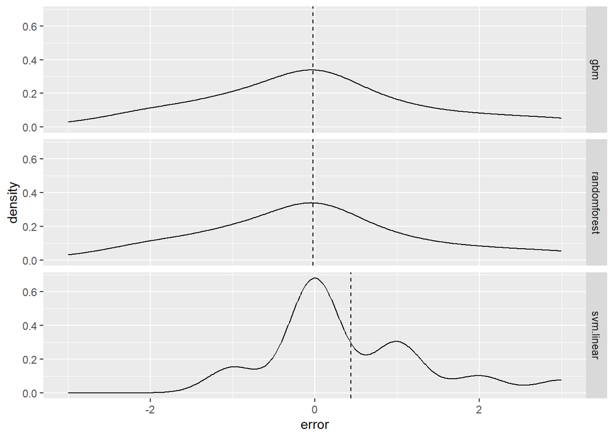

```r
mu <- ddply(df.total, "model", summarise, grp.mean = mean(error))

ggplot(df.total, aes(x = error), color = model) +
  geom_density() +
  facet_grid(model ~ .) +
  geom_vline(data = mu,
             aes(xintercept = grp.mean),
             linetype = "dashed")
```

CONCLUSION :

[output not shown]

Results:

[output not shown]

Based on the results generated above none of the models are considered as ideal.Since my data set is mainly related to the medical field Sensitivity is considered most accurate among st the remaining predictor variables.The model which is able to detect three different types of chest pains but with less amount of accuracy is boosted tree model followed by the SVM linear regression.When the model accuracy is considered the most accurate model is SVM linear model with the value of 0.5192 followed by the random forest and the boosted tree model.

As my data set is mainly collected from the functionality of the human body the room for error is low, a small percentage change in the results could overturn the decision. Based on the accuracy SVM linear regression is considered as the best model.Since in medical field a small change in value subjects to change in a larger picture .So, sensitivity is considered as one the important parameter that needs to be relayed .Based on the sensitivity boosted tree model predicts a small value of prediction on 3 chest diseases among 4.

The statistics/variation in parameter estimates associated with the model imply to a decision-maker to make better decision making in case of booster tree model are :

1)In booster tree model the relative importance of the each predictor variable can be calculated.

2. The variation in parameter estimates can be used to assess the reliability on the model.

Overall the importance of statistics/variation in parameter estimates associated with the model are important considerations for decision makers in evaluating the reliability and usefulness of the model for making decisions.

Based on my understanding of the data set and the analysis of it, in the future I would to regression testing based on the most important and relevant variables generated from all three models.In the future I would be considering more preditor variables that are related to the chest and mainly consider ECG(electro cardiogram)results to get deeper insights of the chest pain type.

My main aim is to use the data collected from the health trackers to gain deeper insights of the human body along with the chest pain.My future work will be mainly focusing on generating cautions on the tracking device if there is any disparity in the human body.